```python
import numpy as np
import matplotlib.pyplot as plt
from scipy.integrate import odeint
```

# 1 Simulation

The first problem is that no .ipynb file was provided.

In essence this is quite similar to the corresponding function in the provided solution, but less thought through.

```python
def pendulum_rhs(zt, dzt, coefficients, terms):
    """
    Compute the scalar product Θ(z, ˙z) · Ξ between the function terms and coefficients
    at the given time points (zt, dzt).

    Parameters:
    - zt: Vector of positions at time points.
    - dzt: Vector of velocities at time points.
    - coefficients: Vector of coefficients.
    - terms: Function representing terms.

    Returns:
    - Scalar product Θ(z, ˙z) · Ξ at each time point.
    """

    # Ensure inputs are NumPy arrays
    zt = np.array(zt)
    dzt = np.array(dzt)

    # Evaluate the terms function at each time point
    terms_values = terms(zt, dzt)

    # Compute the scalar product between terms and coefficients
    scalar_product = np.dot(terms_values, coefficients)

    return scalar_product
```

Again this function is similar to the function in the provided solution. Here terms_values get computed several times. This is some performance concern. In simulate_pendulum the variable y is not defined. This throws an error later. Also the usage of odeint is wrong here. "func" is not a function but the return value of pendulum_ode_step, if y was defined. I didn't test it but "solution = odeint(pendulum_ode_step, initial_state, time_points, args=(coefficients, terms))" should be more correct, also func = pendulum_ode_step(...) should be removed.

```python
def pendulum_ode_step(y, t, coefficients, terms):
    """
    Compute the derivative of the state vector for a pendulum system.

    Parameters:
    - y: Current state vector [z, dz].
    - t: Current time.
    - coefficients: Vector of coefficients.
    - terms: Function representing terms.

    Returns:
    - Derivative of the state vector [dz, ddz].
    """

    z, dz = y  # unpack the state vector
    terms_values = terms(z)  # evaluate terms at the current state

    # Compute the acceleration
    ddz = pendulum_rhs(z, dz, coefficients, terms_values)

    # Return the derivative of the state vector [dz, ddz]
    return [dz, ddz]
def simulate_pendulum(z0, dz0, coefficients, terms, T, dt):

    """
    Simulate a pendulum system using odeint.

    Parameters:
    - z0: Initial position.
    - dz0: Initial velocity.
    - coefficients: Vector of coefficients.
    - terms: Function representing terms.
    - T: Total number of steps.
    - dt: Time step.

    Returns:
    - time_points: Array of time points.
    - solution: Array of state vectors [z, dz] at each time point.
    """

    # Define the time points for simulation
    time_points = np.linspace(0, T * dt, T + 1)

    # Define the initial state vector
    initial_state = [z0, dz0]

    func = pendulum_ode_step(y, t, coefficients, terms)

    # Solve the ODE
    solution = odeint(func, initial_state, time_points, args=(coefficients, terms))

    return time_points, solution
```

This function is too simple regarding the rejection. It is not clear how many samples there will be. Therefore the parameter N becomes close to meaningless, when rejection is enabled. The samples just get thrown away, if the rejection criterion is met. This means that there are probably significantly less simulations than N provided by this function. Also there is no indication when a rejection occurs.

```python
def create_pendulum_data(z0_min, z0_max, dz0_min, dz0_max, coefficients, terms, T, dt, N, embedding=None, rejection=True):
    """
    Create a training set of N simulations from uniform random initial conditions.

    Parameters:
    - z0_min, z0_max: Range of initial positions.
    - dz0_min, dz0_max: Range of initial velocities.
    - coefficients: Vector of coefficients.
    - terms: Function representing terms.
    - T: Total number of steps.
    - dt: Time step.
    - N: Number of simulations.
    - embedding: Type of artificial embedding (e.g., 'cartesian' or 'video').
    - rejection: Flag to enable rejection sampling based on angular momentum.

    Returns:
    - data: List of tuples, each containing time_points and solution for a simulation.
    """
    data = []

    for _ in range(N):
        # Sample random initial conditions
        z0 = np.random.uniform(z0_min, z0_max)
        dz0 = np.random.uniform(dz0_min, dz0_max)

        # Perform rejection sampling if enabled
        if rejection:
            angular_momentum = 0.5 * dz0**2 - np.cos(z0)
            if np.abs(angular_momentum) > 0.99:
                continue  # Reject simulation and sample a new one

        # Simulate the pendulum
        time_points, solution = simulate_pendulum(z0, dz0, coefficients, terms, T, dt)

        """
        # Optionally perform embedding
        if embedding:
            solution = embed_solution(solution, embedding) # Define function for embedding
        """

        # Add the simulation data to the list
        data.append((time_points, solution))

    return data
```

As mentioned previously, the improper usage of odeint causes an error. Also the terms_function returns an array with the same size as z. However in the method pendulum_rhs, the output of this function gets multiplied by the coefficients. In this case this is an 1x2 array. Hence the dims dont match.

```python
N = 100
z0_min = - np.pi
z0_max = np.pi
dz0_min = -2.1
dz0_max = 2.1
T = 50
dt = 0.02

coefficients = np.array([-1, 0])
def terms_function(z, dz):
    return np.sin(z)

data = create_pendulum_data(z0_min, z0_max, dz0_min, dz0_max, coefficients, terms_function, T, dt, N)
```

```
---------------------------------------------------------------------------
NameError                                 Traceback (most recent call last)
Cell In[5], line 13
     10 def terms_function(z, dz):
     11     return np.sin(z)
---> 13 data = create_pendulum_data(z0_min, z0_max, dz0_min, dz0_max, coefficients, terms_function, T, dt, N)

Cell In[4], line 33, in create_pendulum_data(z0_min, z0_max, dz0_min, dz0_max, coefficients, terms, T, dt, N, embedding, rejection)
     30         continue  # Reject simulation and sample a new one
     32 # Simulate the pendulum
---> 33 time_points, solution = simulate_pendulum(z0, dz0, coefficients, terms, T, dt)
     35 """
     36 # Optionally perform embedding
     37 if embedding:
     38     solution = embed_solution(solution, embedding) # Define function for embedding
     39 """
     41 # Add the simulation data to the list

Cell In[3], line 47, in simulate_pendulum(z0, dz0, coefficients, terms, T, dt)
     44 # Define the initial state vector
     45 initial_state = [z0, dz0]
---> 47 func = pendulum_ode_step(y, t, coefficients, terms)
     49 # Solve the ODE
     50 solution = odeint(func, initial_state, time_points, args=(coefficients, terms))

NameError: name 'y' is not defined
```

The code below doesn't really have anything to do with the exercise sheet. It just solves the system of ODEs for the pendulum and plots the results. The system of ODEs is provided directly.

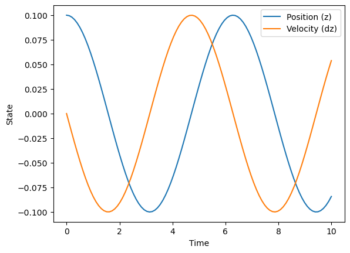

```python
def pendulum_ode_step(y, t):
    z, dz = y
    ddz = -np.sin(z)  # Pendulum equation
    return [dz, ddz]

# Simulate the pendulum
initial_state = [0.1, 0.0]  # Initial conditions [z0, dz0]
time_points = np.linspace(0, 10, 100)
solution = odeint(pendulum_ode_step, initial_state, time_points)

# Plot the results
plt.plot(time_points, solution[:, 0], label='Position (z)')
plt.plot(time_points, solution[:, 1], label='Velocity (dz)')
plt.xlabel('Time')
plt.ylabel('State')
plt.legend()
plt.show()
```